# NR427 Lesson 5A Notebook

Data: Use the RMNP data from 5

https://goo.gl/1N1pce

https://autogis-site.readthedocs.io/en/latest/

http://geopandas.org/index.html

https://www.earthdatascience.org/courses/earth-analytics-python/

#### Import the necessary libraries:

```python
# Import geopandas library, give it the nickname of gpd
import geopandas as gpd
```

1. Create dataframes from source data and plot them

For RMNP Trails:

2. Display the attribute table, columns, descriptive stats, and crs
3. Plot the trails layer with a figsize of 20, 10 and a green line.
4. Test out and plot a few additional tasks: df.centroid, df.envelope, df.convex_hull and understand what they're showing
5. Return the unique values from the UNIT field.

#### 1. Create the necessary dataframes from the source data:

RMNP Lakes  
RMNP Trails  
ElkData - Elk843cow

And plot these layers (individually, or better yet, together on one frame)

```python
# Creating the dataframes
lakesPath = r"C:\Users\xfour\Downloads\RMNPDataLesson4\RMNPDataLesson4\RMNP_Lakes.shp"
trailsPath = r"C:\Users\xfour\Downloads\RMNPDataLesson4\RMNPDataLesson4\RMNP_Trails.shp"
elkData = r"C:\Users\xfour\Downloads\RMNPDataLesson4\RMNPDataLesson4\Elk843cow.shp"

lakesDF = gpd.read_file(lakesPath)
trailsDF = gpd.read_file(trailsPath)
elkDF = gpd.read_file(elkData)
```

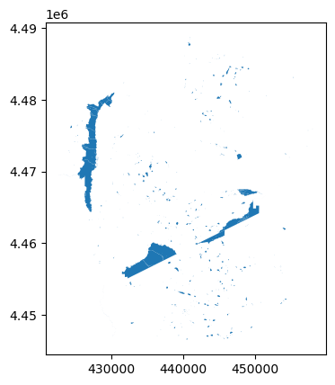

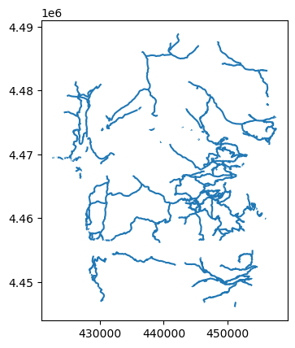

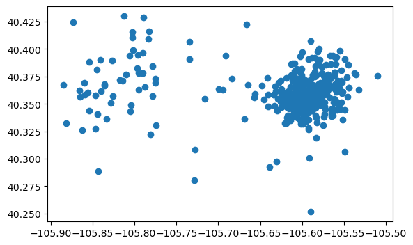

```python
# Visualize the datasets with the needed library and method
lakesDF.plot()
trailsDF.plot()
elkDF.plot()
```

#### 2. Explore basic properties of your trails dataframe:

Return the attribute table, coordinate reference system, number of features, and column names  
Return descriptive stats for the length column  
(Use separate cells for each. Add your own comments or markdown to explain/annotate each step)

```python
# Show the attribute table

trailsDF.head(5)
```

|  | SEGNAME | SEGMENT | UNIT | UNITNUM | STANDARD | USERCLASS | HORSE_USE | CDT | MILES | FEET | SOURCE | OLDNAME | OLDNUM | FMSS | FMSSINFO | geometry |
| --- | --- | --- | --- | --- | --- | --- | --- | --- | --- | --- | --- | --- | --- | --- | --- | --- |
| 0 | COMANCHE PEAK | PO-05 | POUDRE | 10 | E | ALL | Y | None | 2.2 | 11444.5 | 100K USGS | COMANCHE PEAK TRAIL | 81 | 14955 | PO-05 Comanche Peak Trail | LINESTRING (440748.128 4486327.034, 440814.286... |
| 1 | MIRROR LAKE | PO-04 | POUDRE | 10 | E | F | Y | None | 0.8 | 4205.0 | 100K USGS | MIRROR LAKE TRAIL | 80 | 14954 | PO-04 Mirror Lake Trail | LINESTRING (440748.128 4486327.034, 440751.004... |
| 2 | MIRROR LAKE | PO-04 | POUDRE | 10 | E | F | Y | None | 0.5 | 2810.2 | 100K USGS | MIRROR LAKE TRAIL | 80 | 14954 | PO-04 Mirror Lake Trail | LINESTRING (441210.751 4485658.028, 441190.971... |
| 3 | MUMMY PASS, LOWER | PO-02 | POUDRE | 10 | E | ALL | Y | None | 2.6 | 13536.7 | 100K USGS | MUMMY PASS TRAIL | 79 | 14952 | PO-02 Mummy Pass Trail, lower portion | LINESTRING (437228.211 4485348.564, 437299.650... |
| 4 | POUDRE RIVER, LOWER | PO-01 | POUDRE | 10 | E | ALL | Y | None | 0.7 | 3560.8 | 100K USGS | LOWER SECTION POUDRE RIVER TRAIL | 82a | 14951 | PO-01 Poudre River Trail, lower portion | LINESTRING (437228.211 4485348.564, 437210.523... |

```python
# How many trail feautures are there?
len(trailsDF)
```

```
502
```

```python
# Return the crs
trailsDF.crs
```

```
<Projected CRS: EPSG:32613>
Name: WGS 84 / UTM zone 13N
Axis Info [cartesian]:
- E[east]: Easting (metre)
- N[north]: Northing (metre)
Area of Use:
- name: Between 108°W and 102°W, northern hemisphere between equator and 84°N, onshore and offshore. Canada - Northwest Territories (NWT); Nunavut; Saskatchewan. Mexico. United States (USA).
- bounds: (-108.0, 0.0, -102.0, 84.0)
Coordinate Operation:
- name: UTM zone 13N
- method: Transverse Mercator
Datum: World Geodetic System 1984 ensemble
- Ellipsoid: WGS 84
- Prime Meridian: Greenwich
```

```python
# Return the column names, as a nice list
column_names = trailsDF.columns.tolist()
print(column_names)
```

```
['SEGNAME', 'SEGMENT', 'UNIT', 'UNITNUM', 'STANDARD', 'USERCLASS', 'HORSE_USE', 'CDT', 'MILES', 'FEET', 'SOURCE', 'OLDNAME', 'OLDNUM', 'FMSS', 'FMSSINFO', 'geometry']
```

```python
# Get some descriptive statistics for a numeric column with df.fieldname.describe()

trailsDF.MILES.describe()
```

```
count    502.000000
mean       0.700398
std        0.920188
min        0.000000
25%        0.100000
50%        0.400000
75%        0.900000
max        5.500000
Name: MILES, dtype: float64
```

#### 3. Plot trails with a figure size of 20 by 10 and a green line.

Some matplotlib help and samples:

https://www.geeksforgeeks.org/simple-plot-in-python-using-matplotlib/

https://matplotlib.org/stable/gallery/lines_bars_and_markers/simple_plot.html

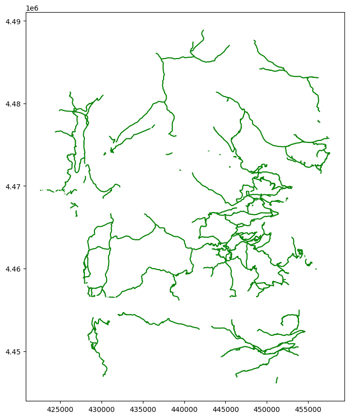

```python
import matplotlib.pyplot as plt



trailsplot = trailsDF.plot(color='green', figsize=(20, 10))
```

#### 4. Test out and plot geometry operations: centroid, envelope, convex_hull

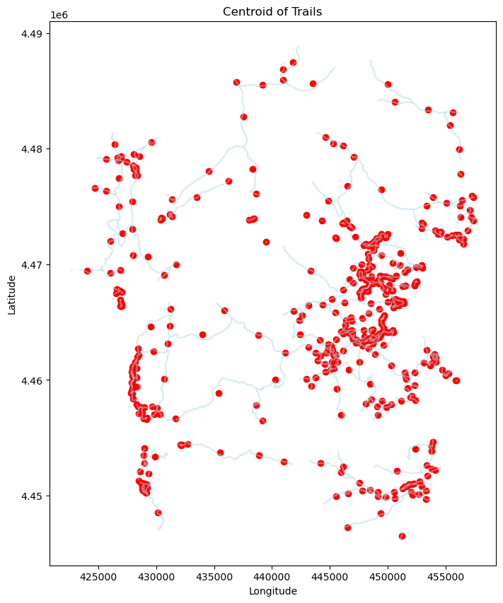

```python
centroids = trailsDF.geometry.centroid

fig, ax = plt.subplots(figsize=(20, 10))
trailsDF.plot(ax=ax, color='lightblue', alpha=0.5)
centroids.plot(ax=ax, color='red', marker='o')

ax.set_title('Centroid of Trails')
ax.set_xlabel('Longitude')
ax.set_ylabel('Latitude')
plt.show()
```

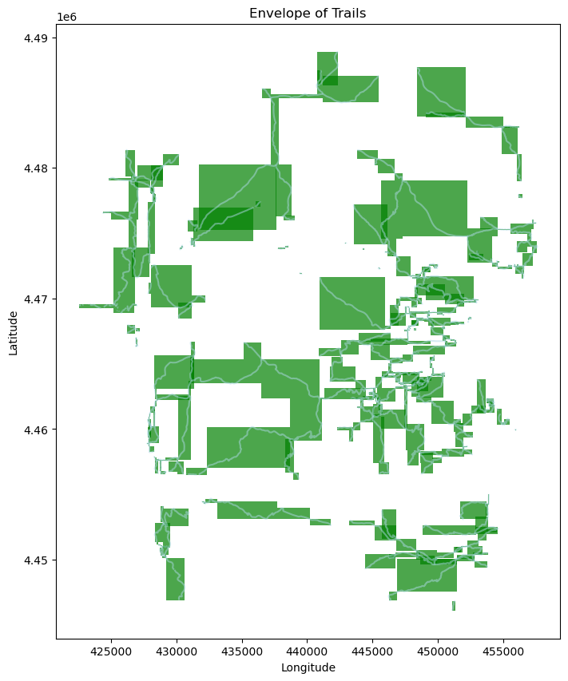

```python
envelopes = trailsDF.geometry.envelope

fig, ax = plt.subplots(figsize=(20, 10))
trailsDF.plot(ax=ax, color='lightblue', alpha=0.5)
envelopes.plot(ax=ax, color='green', linestyle='--', alpha=0.7)

ax.set_title('Envelope of Trails')
ax.set_xlabel('Longitude')
ax.set_ylabel('Latitude')
plt.show()
```

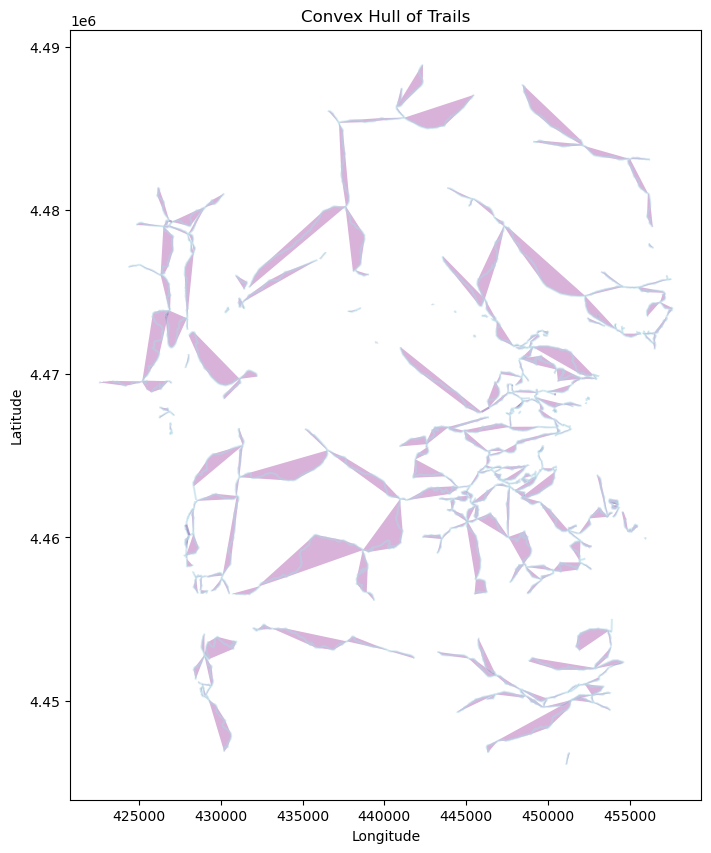

```python
convex_hulls = trailsDF.geometry.convex_hull

fig, ax = plt.subplots(figsize=(20, 10))
trailsDF.plot(ax=ax, color='lightblue', alpha=0.5)
convex_hulls.plot(ax=ax, color='purple', alpha=0.3)

ax.set_title('Convex Hull of Trails')
ax.set_xlabel('Longitude')
ax.set_ylabel('Latitude')
plt.show()
```

#### 5. Return the unique values from the UNIT field, nicely formatted

```python
unique_units = trailsDF['UNIT'].unique()


print("Unique 'UNIT' values:")
for unit in unique_units:
    print(unit)
```

```
Unique 'UNIT' values:
POUDRE
NORTH FORK
BLACK CANYON/ROARING RIVER
NEVER SUMMER
TRAIL RIDGE
FRONT RANGE
KAWUNEECHE VALLEY
WEST VALLEYS
LONGS PEAK
WILD BASIN
```

#### 1. Get/Select the trails that belong to the FRONT RANGE unit (Use the UNIT field)

Plot the convex hull of just the FRONT RANGE unit trails

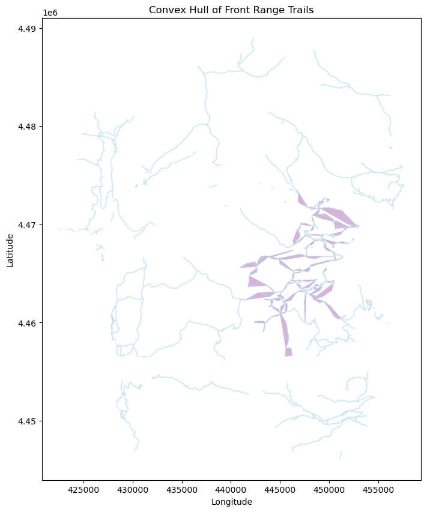

```python
front_range_trails = trailsDF[trailsDF['UNIT'] == 'FRONT RANGE']

convex_hulls = front_range_trails.geometry.convex_hull

fig, ax = plt.subplots(figsize=(20, 10))
trailsDF.plot(ax=ax, color='lightblue', alpha=0.5)
convex_hulls.plot(ax=ax, color='purple', alpha=0.3)

ax.set_title('Convex Hull of Front Range Trails')
ax.set_xlabel('Longitude')
ax.set_ylabel('Latitude')
plt.show()
```

#### 2. Buffer the selected Front Range trails by 300m, plot the result

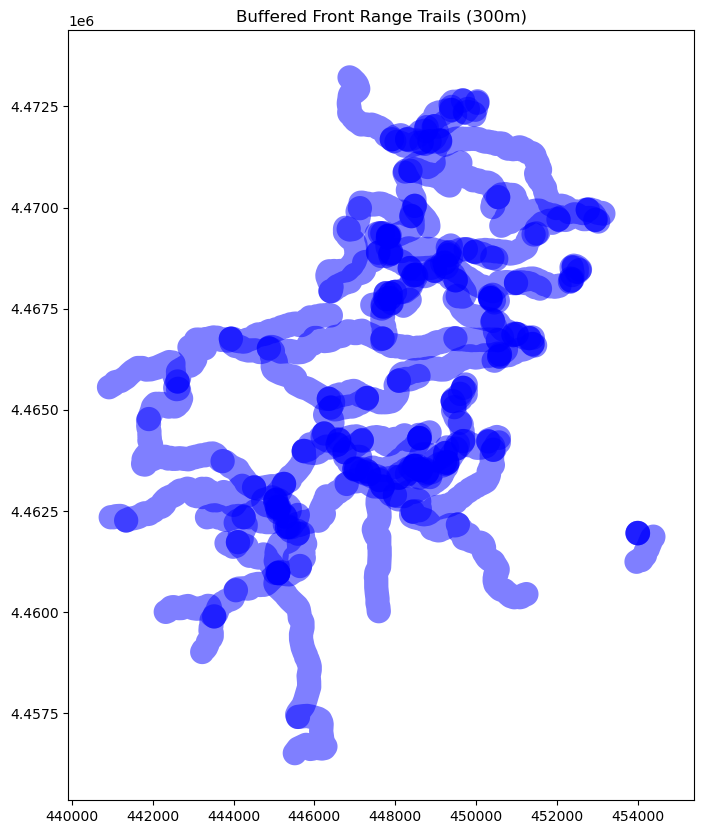

```python
front_range_buffered = front_range_trails.buffer(300)

fig, ax = plt.subplots(figsize=(20, 10))


front_range_buffered.plot(ax=ax, color='blue', alpha=0.5)


ax.set_title('Buffered Front Range Trails (300m)')


plt.show()
```

#### 3 / 4. If the CRS's for Elk843cow and Trails match, perform the proper overlay operation to find all the Elk points that are within 300m of a Front Range trail.

If they don't match, convert the CRS, then do the overlay.

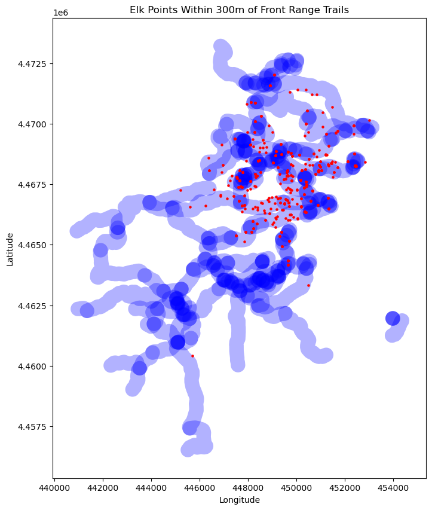

```python
if elkDF.crs != trailsDF.crs:

    elkDF = elkDF.to_crs(trailsDF.crs)

front_range_buffered = front_range_trails.buffer(300)

buffered_trails_gdf = gpd.GeoDataFrame(geometry=gpd.GeoSeries(front_range_buffered), crs=elkDF.crs)


elk_near_trails = gpd.sjoin(elkDF, buffered_trails_gdf, how='inner', predicate='intersects')

fig, ax = plt.subplots(figsize=(20, 10))

buffered_trails_gdf.plot(ax=ax, color='blue', alpha=0.3, label='300m Buffer Zone')

elk_near_trails.plot(ax=ax, color='red', marker='o', markersize=5, label='Elk Points Near Trails')

ax.set_title('Elk Points Within 300m of Front Range Trails')
ax.set_xlabel('Longitude')
ax.set_ylabel('Latitude')


plt.show()
```